# Utiliser R Markdown pour créer des documents dynamiques

### Modifier le mode d’evaluation du code

Par défaut, avec `rmarkdown`, dans un bloc de code R, le code est exécuté par R et les sorties sont ajoutées dans le document. Ci-dessus, nous avons vu comment modifier ce qui est présenté dans le code source et changer certain aspect de la sortie. Il est également possible de modifier l’exécution du code.

#### Enlever toutes sorties

Dans certains cas, il peut s’avérer utile de montrer le code source sans l’exécuter. Pour empêcher l’évaluation du code, on utilise `eval = FALSE`. Ainsi, avec

````
``{r eval, eval = FALSE}
install.packages(`rmarkdown`)
```
````

l’installation du package `rmarkdown` n’est pas exécutée mais bien affichée :

```r
install.packages(`rmarkdown`)
```

On peut aussi utiliser un blocs de code sans accolade

````
``r
install.packages(`rmarkdown`)
```
````

```r
install.packages(`rmarkdown`)
```

Une des raisons de préférer `eval = FALSE` à un bloc sans accolade est la possibilité de suspendre l’évaluation d’un bloc de code tout en conservant les autres paramètres dans l’accolade, ce qui est très pratique lorsqu’on développe du contenu avec R Markdown.

#### Exécuter le code silencieusement

Un autre cas relativement commun avec utilise R Markdown est de vouloir exécuter de manière silencieuse. En d’autres termes, on ne veut ni présenter le code ni aucune sortie, mais le code doit avoir été exécuté. Dans un rapport dynamique, par exemple, on est souvent amener à exécuter un script ou charger des fonctions qui serviront plus bas à créer des sorties qui seront intégrer dans le rapport. Avec ce qui a été vu précédemment, on sait qu’en utilisant les options `echo = FALSE`, `results = hide`, `message = FALSE` et `warning = FALSE` ensemble dans l’accolade, on est capable de d’arriver à ce résultat. Il existe cependant une manière plus rapide d’arriver à ce résultat en utilisant `include = FALSE` qui exécute le code silencieusement. Ci-dessous je créé une fonction qui fait une addition simple et j’assigne le résultat à la variable `res`

````
``{r include, include = FALSE}
mon_addition <- function(a, b) {
    return(a + b)
}
res <- mon_addition(2, 3)
```
````

Ci-dessous j’utilise ce bloc de code …

… et, comme attendu, ni code ni sortie ne sont retournés, mais pourtant le code a bien été exécuté, et donc si je demande l’affichage de `res`

```r
print(res)
```

```
## [1] 5
```

j’obtiens bien 5 et je peux également utiliser ma fonction `mon_addition()` :

```r
mon_addition(12, 30)
```

```
## [1] 42
```

## Tables et figures

Les remarques de la section précédente sont valides pour tout type de sortie. Les tables et les figures créées avec R sont des sorties très souvent utilisées qu’il est bon de savoir personnaliser davantage.

### Tables

Avec le package `knitr`, il est possible d’intégrer dans le texte une table créée sous R. Commençons par créer un objet `data.frame` :

```r
var1 <- 20 * runif(12)
tab1 <- data.frame(
    experience = paste0("traitement_", rep(1:3, each = 4)),
    replicat = rep(letters[1:4], 3),
    var1 = var1,
    var2 = var1 + rnorm(12)
    )
```

La fonction *kable()* du package `knitr` nous permet d’obtenir notre object *tab1* en différents formats (dont “latex”, “html”, “markdown”). Ici, en utilisant “markdown” par défaut on aura une table qui sera convertie dans le format désiré par Pandoc. De plus, la fonction *kable()* inclut le paramètre `caption` pour ajouter une légende.

````
``{r table1}
library(knitr)
kable(tab1, caption = "Table créée à partir de *df1*")
```
````

```r
library(knitr)
kable(tab1, caption = "Table créée à partir de *df1*")
```

Table créée à partir de *df1*

| experience | replicat | var1 | var2 |
| --- | --- | --- | --- |
| traitement_1 | a | 9.449713 | 10.294380 |
| traitement_1 | b | 5.945522 | 6.076179 |
| traitement_1 | c | 15.071473 | 15.558200 |
| traitement_1 | d | 1.021521 | 1.442371 |
| traitement_2 | a | 10.691655 | 11.955292 |
| traitement_2 | b | 14.008719 | 14.088486 |
| traitement_2 | c | 6.833213 | 7.660623 |
| traitement_2 | d | 12.131596 | 14.350571 |
| traitement_3 | a | 11.623614 | 10.626275 |
| traitement_3 | b | 4.124332 | 2.622451 |
| traitement_3 | c | 19.575213 | 19.394710 |
| traitement_3 | d | 6.220960 | 6.114742 |

Il y a bien d’autre paramètres dans la fonction *kable()*, par exemple, il est possible de choisir le nombre de chiffres utilisés utiliser après la virgule ou encore d’inclure les numéros de lignes.

````
``{r table2}
kable(tab1, caption = "Table créée à partir de *df1*", digits = 3, row.names = TRUE)
```
````

```r
kable(tab1, caption = "Table créée à partir de *df1*", digits = 3, row.names = TRUE)
```

Table créée à partir de *df1*

|  | experience | replicat | var1 | var2 |
| --- | --- | --- | --- | --- |
| 1 | traitement_1 | a | 9.450 | 10.294 |
| 2 | traitement_1 | b | 5.946 | 6.076 |
| 3 | traitement_1 | c | 15.071 | 15.558 |
| 4 | traitement_1 | d | 1.022 | 1.442 |
| 5 | traitement_2 | a | 10.692 | 11.955 |
| 6 | traitement_2 | b | 14.009 | 14.088 |
| 7 | traitement_2 | c | 6.833 | 7.661 |
| 8 | traitement_2 | d | 12.132 | 14.351 |
| 9 | traitement_3 | a | 11.624 | 10.626 |
| 10 | traitement_3 | b | 4.124 | 2.622 |
| 11 | traitement_3 | c | 19.575 | 19.395 |
| 12 | traitement_3 | d | 6.221 | 6.115 |

Pour en apprendre davantage, reportez-vous à la documentation de cette fonction. Le package [`kableExtra`](https://cran.r-project.org/web/packages/kableExtra/vignettes/awesome_table_in_html.html) offre de très nombreuses fonctionnalités pour créer des tableaux plus complexes, je vous recommande chaudement d’y jeter un coup d’œil.

### Figures

Avec le package `rmarkdown`, il est très facile d’insérer les figures produites avec R dans un document, le plus simple est de regarder ce que génère un simple plot généré avec la fonction `plot()`. Je reprends le data frame créer plus haut pour cela.

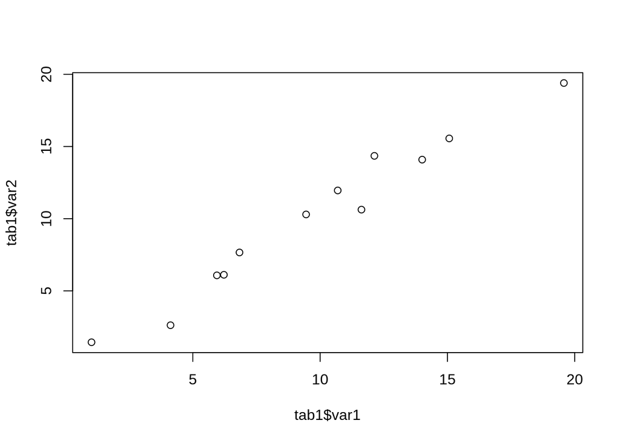

```r
plot(tab1$var1, tab1$var2)
```

J’obtiens la figure demandée, avec des dimensions par défaut qui prennent une bonne de la largeur du document, mais pas son entièreté. Pour formater une figure obtenue avec R, il existe des options pour contrôler, entre autres, sa taille, son alignement et sa légende (taille et alignement ne sont pas supportés pour la sortie Word). Pour visualiser l’ensemble des options disponibles, je vous invite à regarder la page 3 du [guide de référence](http://www.rstudio.com/wp-content/uploads/2015/03/rmarkdown-reference.pdf). Dans le bloc de code ci-dessous, la taille de la figure et son alignement sont ajustés et une légende est ajoutées.

````
``{r figdim1, fig.cap = "Ceci est la légende de la figure",
    fig.height = 4, fig.width = 4, fig.align = 'right'}
plot(tab1$var1,tab1$var2)
```
````

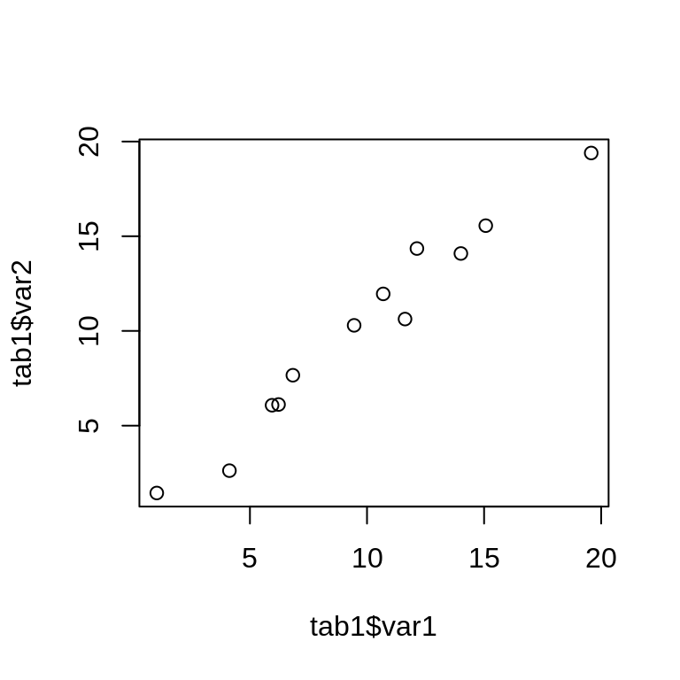

```r
plot(tab1$var1, tab1$var2)
```

````
``{r figdim2, fig.cap= "Figure 9x6", fig.width = 9, fig.aspect = 1.5}
plot(tab1$var1,tab1$var2)
```
````

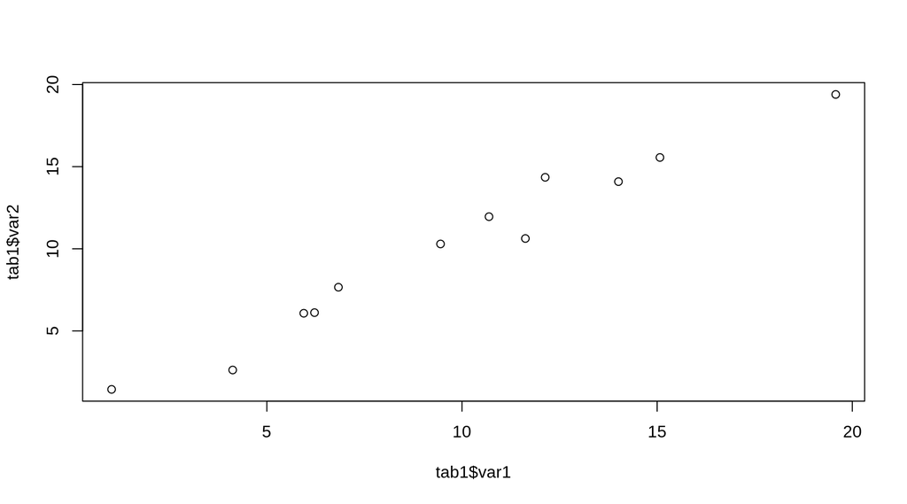

```r
plot(tab1$var1,tab1$var2)
```

Il est aussi possible de contrôler la largeur de la sortie en utilisant des pourcentage, pour cela on utilise `out.width`

````
``{r figdim3, out.width = "100%"}
plot(tab1$var1, tab1$var2)
```
````

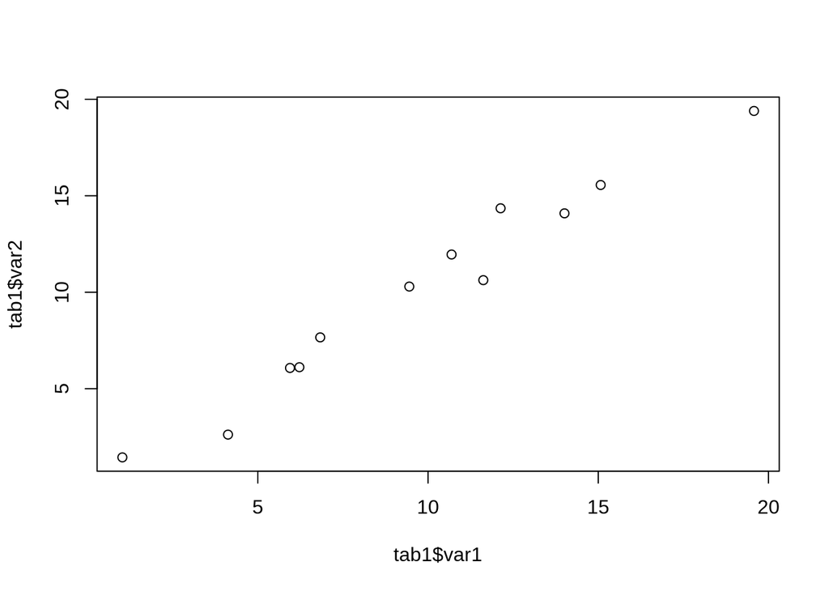

```r
plot(tab1$var1, tab1$var2)
```

Il est aussi possible de changer le format de sortie des figures peut être choisi avec le paramètre `dev` (la liste complète des formats est disponible à https://yihui.org/knitr/options/).

[output not shown]